# All Morphology: Testing for Spatial Dependencies

## Model Validation, Variograms, and Spatial Plots

A **variogram** is used to display the variability between data points as a function of distance. Here, from distances 0 to 4000 m, the variability between points starts high and then decreases (the points become more similar) until it levels out because at some point the distance between data points will be great enough that the points are no longer considered to be related to each other. The variability will flatten out into a “sill”.

```r
temp = d2
dt = check_spatial_dependencies(M2, temp, temp$long, temp$lat, zone = 16, cutoff=10000, is_inla=TRUE)
```

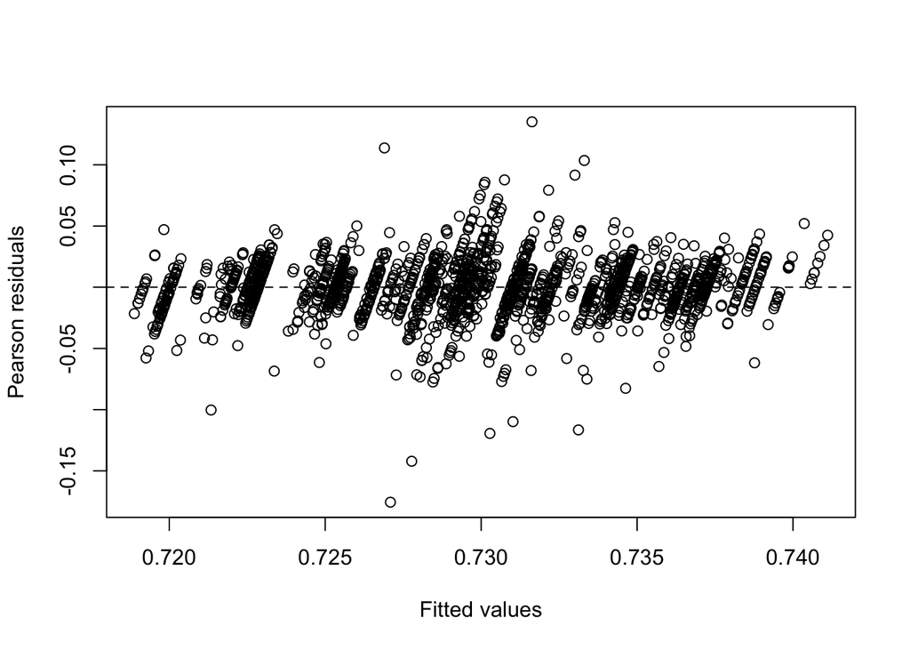

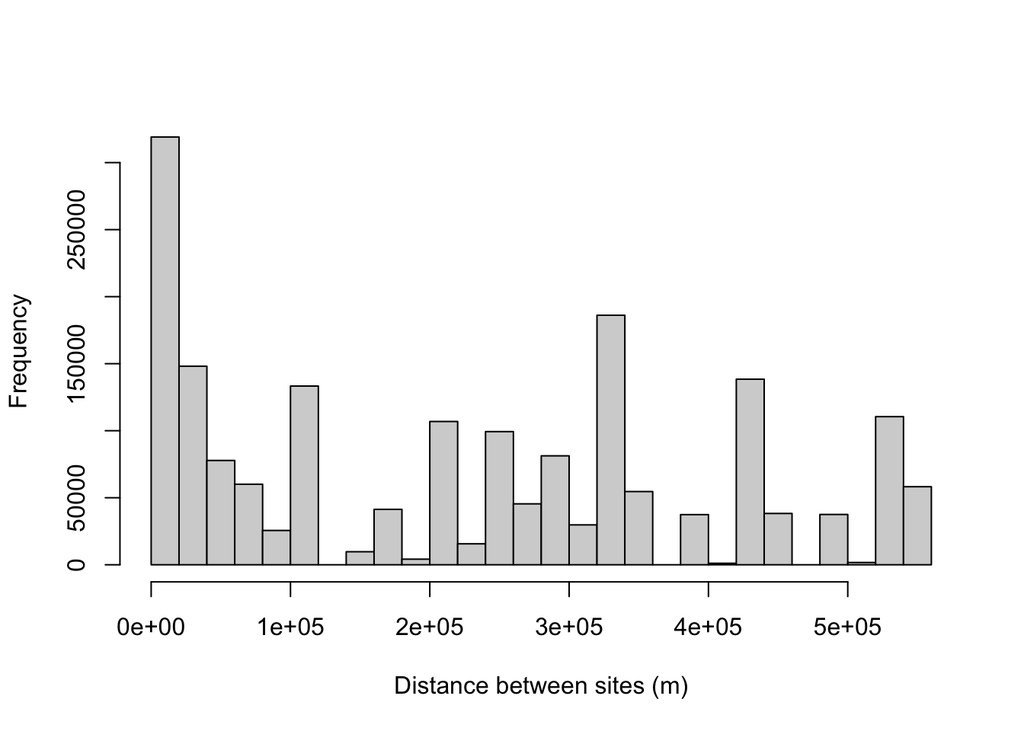

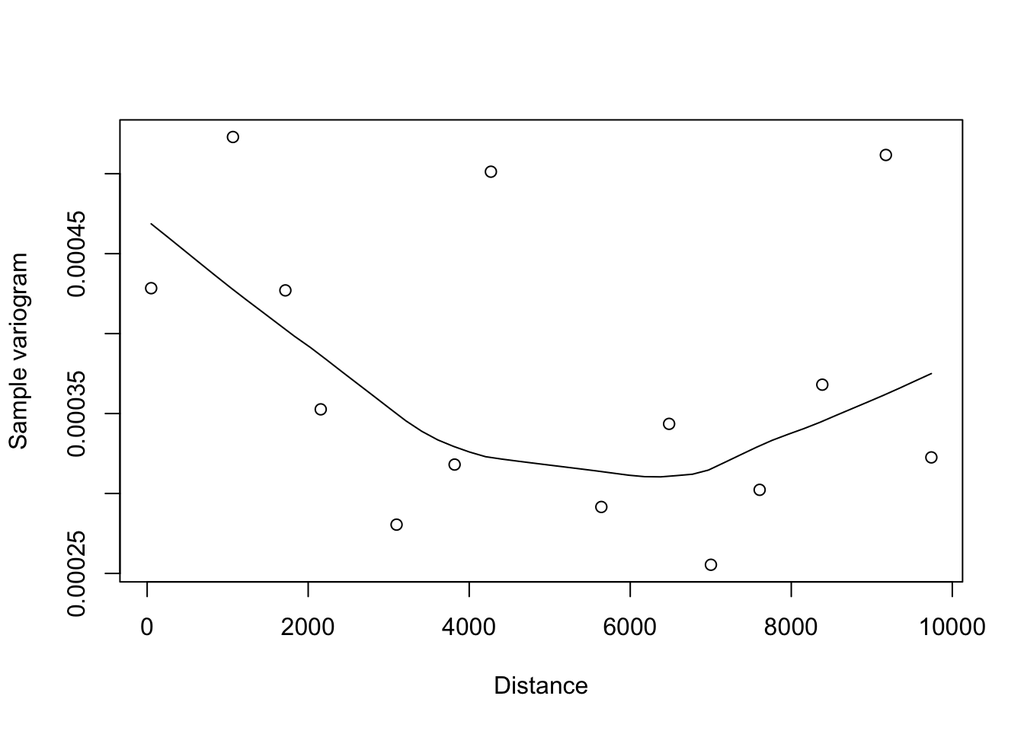

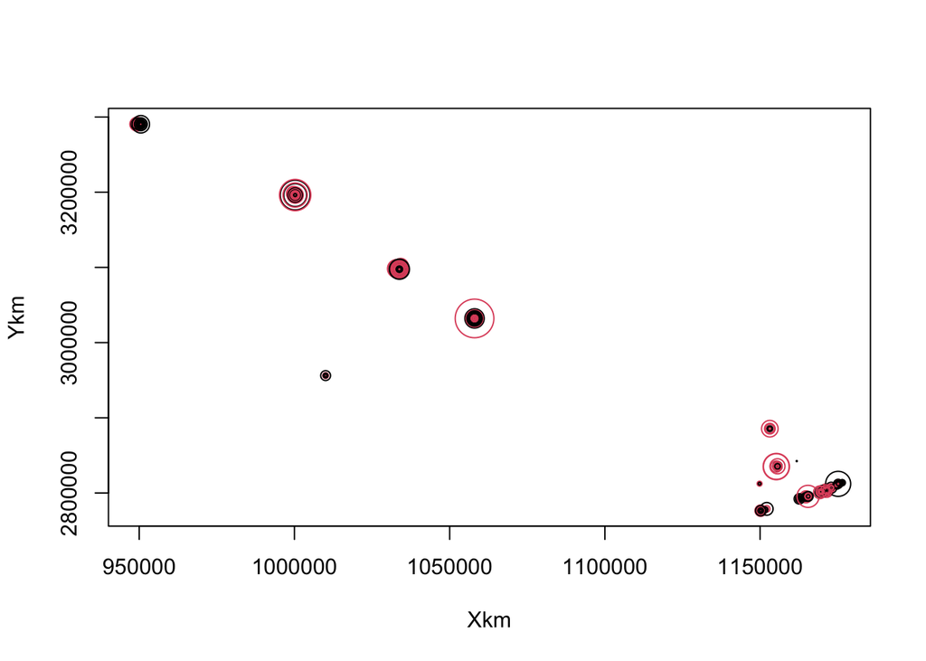

## Model Ony the Keys and Homestead

```r
keys = c("North_Key_Largo", "Key_Largo", "Plantation_Key", "Homestead", "HomesteadBV", "HomesteadGRT")

d3 = d2 %>%
  filter(population == "North_Key_Largo" | population =="Key_Largo" | population == "Plantation_Key" | population == "Homestead" | population == "HomesteadBV" | population == "HomesteadGRT")
```

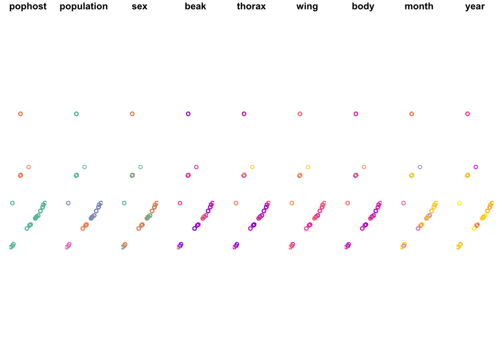

```r
spatial_data <- st_as_sf(d3,
                         coords = c("long", "lat"),
                         crs = 4326,
                         agr = "constant")

spatial_data <- st_transform(spatial_data, 2236)
plot(spatial_data)
```

```r
M1 <- inla(wing2body ~ sex_binom + pophost + month_of_year + months_since_start +
                    f(population, model = "iid"),
                    control.compute = list(dic = TRUE),
                    family = "gaussian",
                    data = d3)
```

```r
temp = d3
dt = check_spatial_dependencies(M1, temp, temp$long, temp$lat, zone = 16, cutoff=10000, is_inla=TRUE)
```

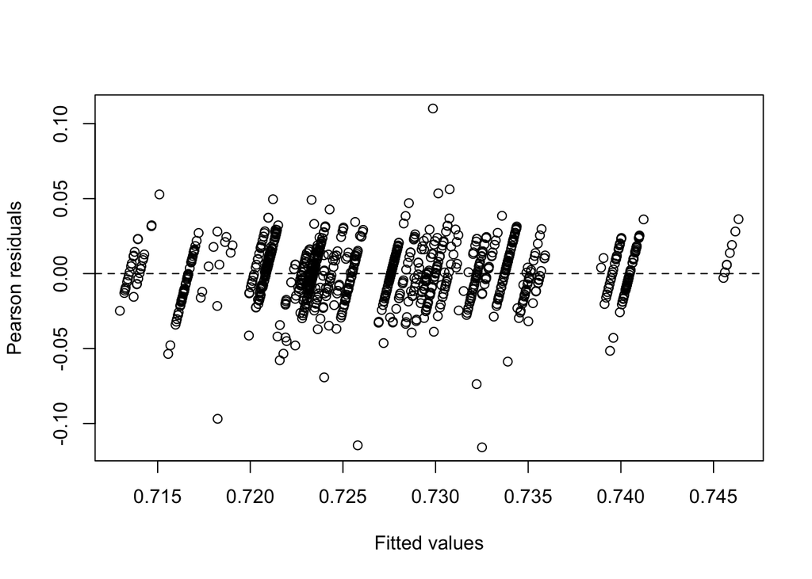

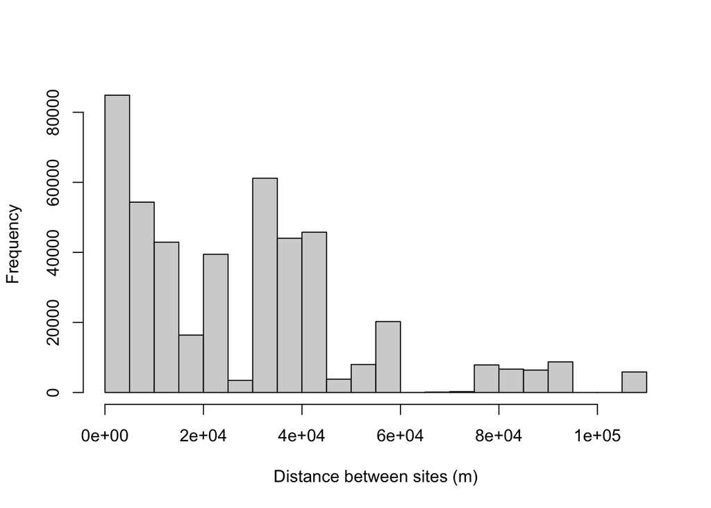

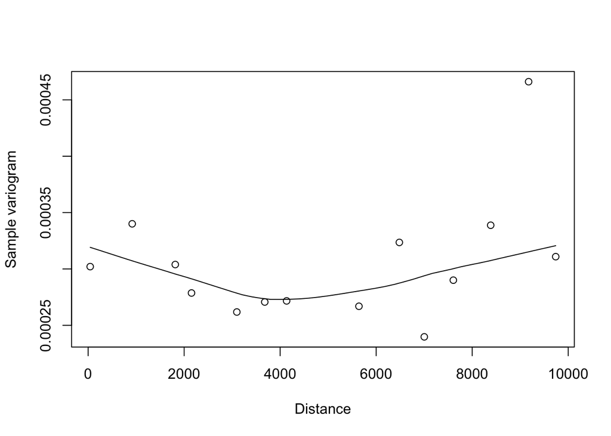

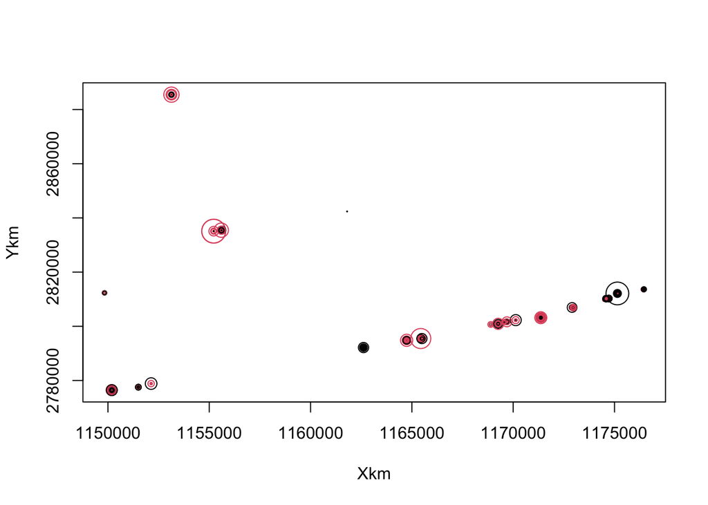

## Model Only Keys

```r
d4 = d2 %>%
  filter(population == "North_Key_Largo" | population =="Key_Largo" | population == "Plantation_Key")
```

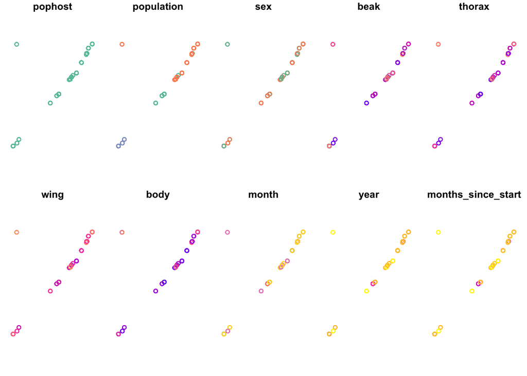

```r
spatial_data <- st_as_sf(d4,
                         coords = c("long", "lat"),
                         crs = 4326,
                         agr = "constant")

spatial_data <- st_transform(spatial_data, 2236)
plot(spatial_data)
```

```r
M1 <- inla(wing2body ~ sex_binom + month_of_year + months_since_start +
                    f(population, model = "iid"),
                    control.compute = list(dic = TRUE),
                    family = "gaussian",
                    data = d4)
```

```r
temp = d4

d4 = check_spatial_dependencies(M1, temp, temp$long, temp$lat, zone = 16, cutoff=10000, is_inla=TRUE)
```

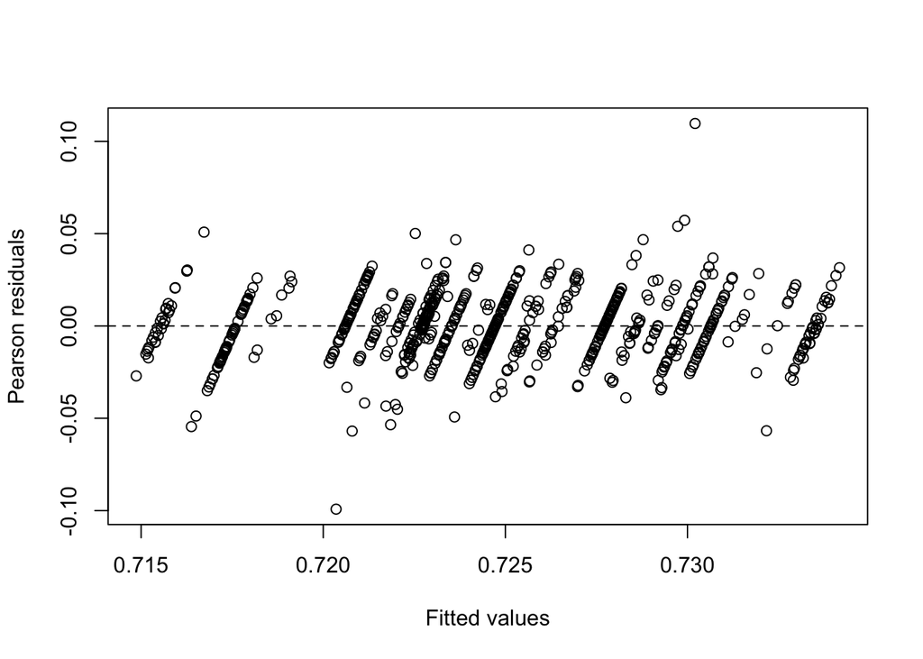

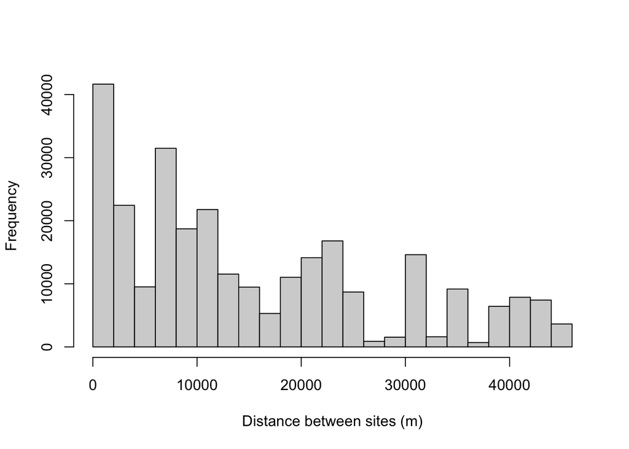

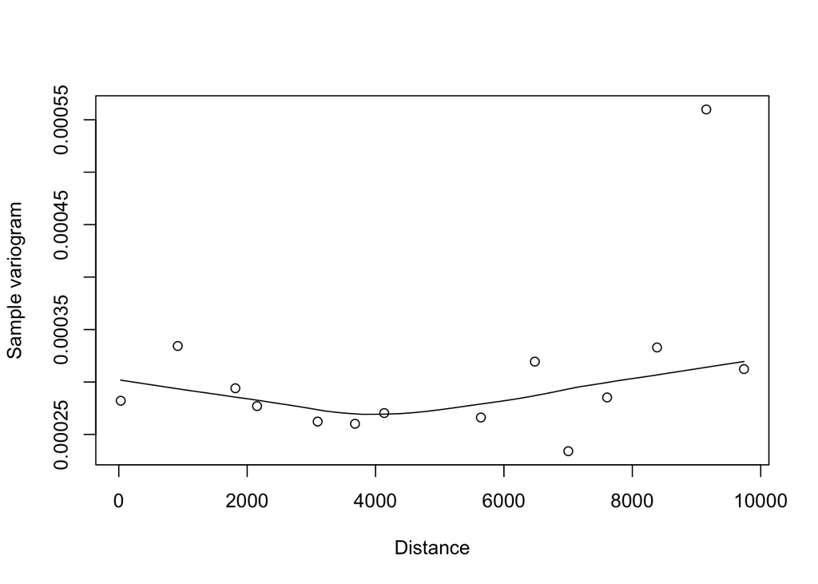

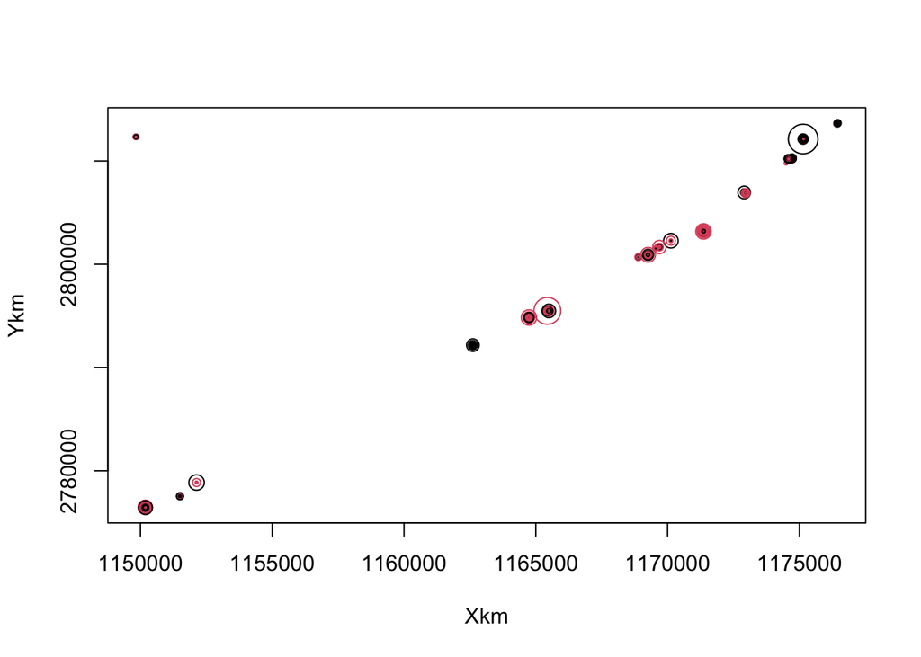

Probably best to take some means because the layering is obscuring what is happening per site, but can see clustering regardless.